# White Wine Exploration by Adrian Ciubotaru

### Plot Three

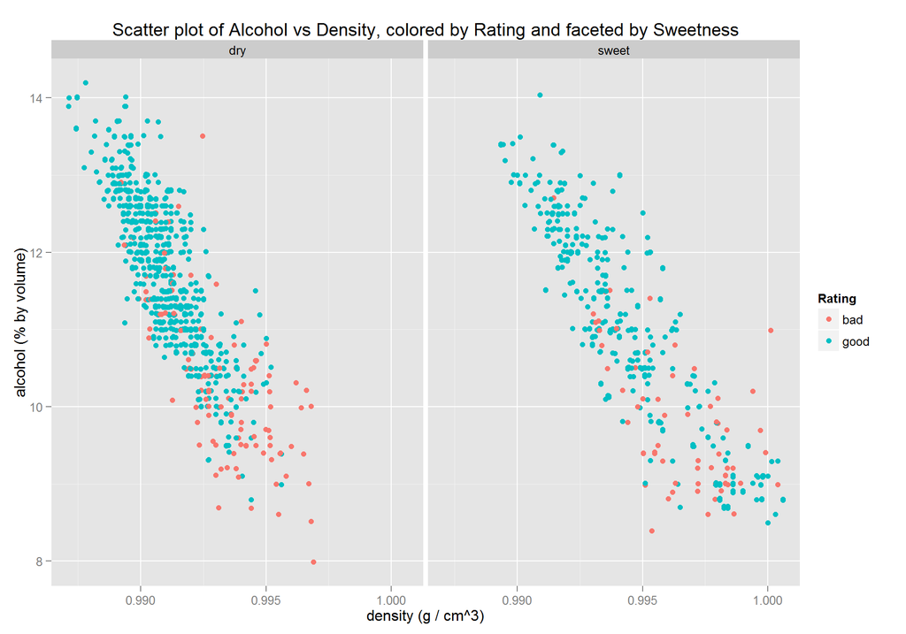

### Description Three

##### This plot reflects the relationship between alcohol, residual sugar, density and quality.

##### As I expected, there is a big clustering of good wines in the top left corner. This is explainable since alcohol was the biggest predictor in wine quality and density is negatively correlated with alcohol () high alcohol content, this results in a low density).

##### A big surprise however, is the small cluster of good wines in the section where I expected to find mostly bad wines. Since that section is described by wines with high density, I naturally thought that the other variable that affects density causes this effect, namely residual sugar. Sure enough, after faceting the plot for wines under and over the median sugar content, I discovered that residual sugar is the variable that explaines that unexpected clustering.

# Reflection

##### I found this project to be both challenging and rewarding. It was a great experience for me to start exploring the data set from different angles, uconvering new relationships in the data and moving past the apparent dead ends.

##### One of the biggest challenges for me was to decide on what is relevant. Since I am not a wine connaiseur I felt a bit overwhelmed by the selection of data. I had no ideea where to start, so I decided on exploring each and every single one of the variables. This felt a bit repetitive, but it was a great way to get familiarised with the data set.

##### After exploring the data in such a way, another challenge for me was the fact that I did no find any imediate or obvious answers to my initial question: ‘What makes a wine good?’. I felt almost as lost as in the beginning, after seing the small correlation coefficients in the correlation matrix. But having decided to persevere in uncovering the hidden patterns, I gradually found it easier and easier to navigate through the data.

##### All this being said, I felt a great sense of acomplishment after uncovering the relationship between alcohol, density, sugar and quality, so beautifully layed out in the third plot that I selected. I do not feel much better qualified to give an opinion on wines, but that was never the objective. This data set is only a small selection of wines of a very specific type after all.

##### Moving forward, my current analysis could be improved in more than a few ways. For example, a multiple regression model could be fitted in order to explore the predictive capacity of the selected variables. Also, I am almost certin that there are meaningful connections that I have failed to explore. I only went after variables that scored the highest correlation coefficients, and I also do not have any previous knowledge of factors that might be obvious to people who are knowledgeable about wines.

##### All this being said, the most valuable takeaway for me is the fact that I now feel much more comfortable with exploring data, and digging deeper and deeper to find the answers that I am looking for.

### Sources

- [Stack Overflow](https://stackoverflow.com)
- [R Documentation - dplyr](https://www.rdocumentation.org/packages/dplyr)
- [ggcorr](https://briatte.github.io/ggcorr/#controlling-the-coefficient-labels)
- [Reverting a matrix](https://stat.ethz.ch/pipermail/r-help/2008-September/175012.html)